# Chapter 16 - SC

Alan T. Arnholt

Last compiled: February 14, 2022 at 08:43:47 AM

# 1 Sampling Distribution Models and Confidence Intervals for Proportions

**Objectives:**

1. Sampling distribution idea
2. Learn distribution of $\hat{p}$
3. Use distribution to solve problems

Every sample is different, so each value of the statistic will be slightly different, but based on the distribution (taking an infinite number of samples), we can estimate the shape, center, and spread of what all those samples would give.

Use the `phatfunc()` to simulate a Bernoulli random variable with $n =$ 81, 256, and 625, with $p =$ 0.6, 0.8, and 0.3, respectively. Fill in the table with the estimated means, standard deviations, and shape of the simulated sampling distribution of $\hat{p}$ using the specified values for $n$ and $p$.

```r
phatfunc <- function(m = 10000, n, p) {
  trialvals <- sample(c(0, 1), m*n,
                      replace = TRUE, prob = c(1-p, p))
  trialmat <- matrix(trialvals, ncol = n)

  NumSuccesses <- apply(trialmat, 1, sum)
  Phats <- NumSuccesses/n
  ans <- c(mean(Phats), sd(Phats))
  names(ans) <- c("MeanPhat", "StdDevPhat")
  hist(Phats,
   breaks = seq(from = min(Phats), to = max(Phats),
                by = 1/n),
       col = "lightblue", freq = FALSE,
       xlab = expression(hat(p)),
       ylab = "",
       main = "Histogram of Simulated p-hats")
  curve(dnorm(x, p, sqrt(p*(1-p)/n)),
        add = TRUE, col = "blue", lwd = 2)
  return(ans)
}
```

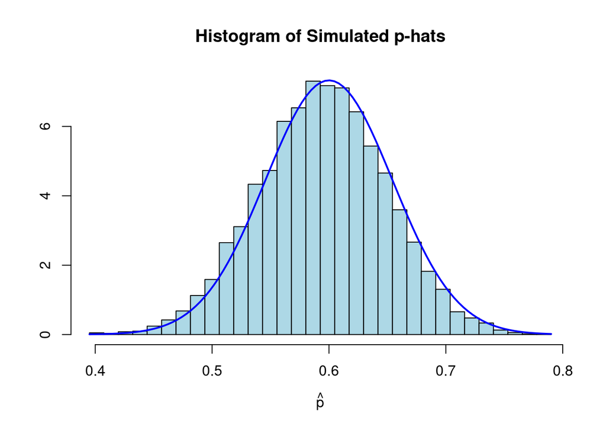

```r
# Remove below
phatfunc(n = 81, p = 0.6) -> ans1
```

```r
ans1
```

```
  MeanPhat StdDevPhat
0.60060370 0.05475054
```

```r
## Finish for the other values of n and p
```

| $n$ | $p$ | $\hat{\mu}_{\hat{p}}$ | $\hat{\sigma}_{\hat{p}}$ | shape |
| --- | --- | --- | --- | --- |
| 81 | 0.6 | 0.6006037 | 0.0547505 | Normal |
| 256 | 0.8 |  |  |  |
| 625 | 0.3 |  |  |  |

In general, if the sample size is large enough and data are drawn so that each success or failure is independent,

$$\hat{p} \sim \mathcal{N}\left(\mu_{\hat{p}} = p, \sigma_{\hat{p}}= \sqrt{\frac{p(1-p)}{n}} \right).$$

**Conditions** To check “large enough” and independence, three conditions must be met:

1. **Randomization**—data are drawn with a simple random sample OR the sample is unbiased and representative of the population.
2. **10%**—Less than 10% of the population is sampled.
3. **Success/Failure**— both $n\hat{p}$ and $n(1-\hat{p})$ are greater than or equal to 10.

## Example

It is known that red/green colorblindness affects 7% of American men. A school district gives tests to 233 incoming kindergarten males.

1. Define your random variable.

**ANSWER:** Let $\hat{p}=$

2. Check three conditions.

**ANSWER:**

3. Give the sampling distribution of $\hat{p}$.

**ANSWER:**

4. What is the probability that more than 10% of these kindergarten males will be colorblind?

**ANSWER:** $P(\hat{p} \geq 0.10) = 1 - P(\hat{p} \leq 0.10) =$

```r
pnorm(.10, 0.07, sqrt(.07*.93/233), lower = FALSE)
```

```
[1] 0.0363452
```

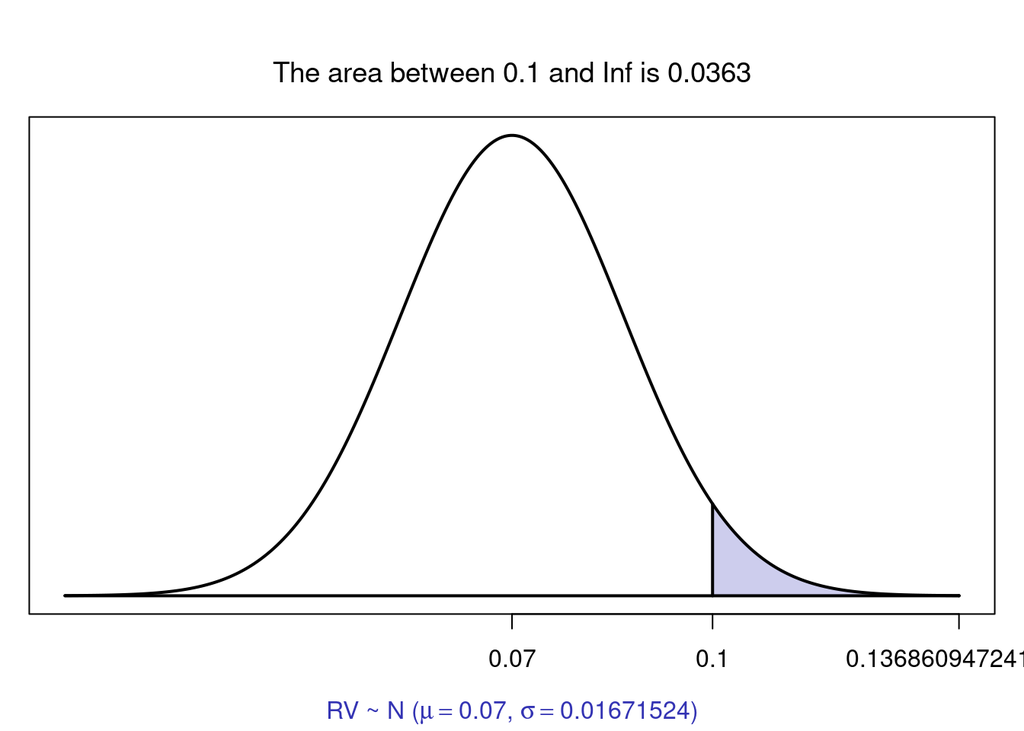

```r
library(PASWR2)
normarea(.10, Inf, 0.07, sqrt(.07*.93/233))
```

5. What is the probability that fewer than 5% will be colorblind?

**ANSWER:** $P(\hat{p} \leq 0.05) =$

```r
# YOUR CODE HERE
```

6. What is the probability that between 8% and 12% will be colorblind?

**ANSWER:** $P(0.08 \leq \hat{p} \leq 0.12) =$

```r
# YOUR CODE HERE
```

7. What is the $75^{\text{th}}$ percentile of the percent who are colorblind?

**ANSWER:** $P(\hat{p} \leq q) = 0.75 \rightarrow q =$

```r
# YOUR CODE HERE
```

8. How many standard deviations from the mean would an unusual observations be? **XX** Rare? **XXX**
9. How can you reduce the standard deviation in half?

**ANSWER:**

**Objectives:**

1. Review $\mathcal{N}(0, 1)$
2. Derive confidence interval for $p$
3. Use CI formula to solve problems
4. Explore idea of a CI
5. Derive and use required sample size formula
- Recall that if $X \sim \mathcal{N}(\mu, \sigma)$, then $z = \frac{x - \mu}{\sigma} \sim \mathcal{N}(0, 1)$.
- Draw pictures of $z_{0.08}$, $z_{0.9}$, between area with numbers, between area with $\alpha$. Note that $z_{\alpha} = -z_{1 - \alpha}$.

```r
z1 <- qnorm(0.08, 0, 1)
z1
```

```
[1] -1.405072
```

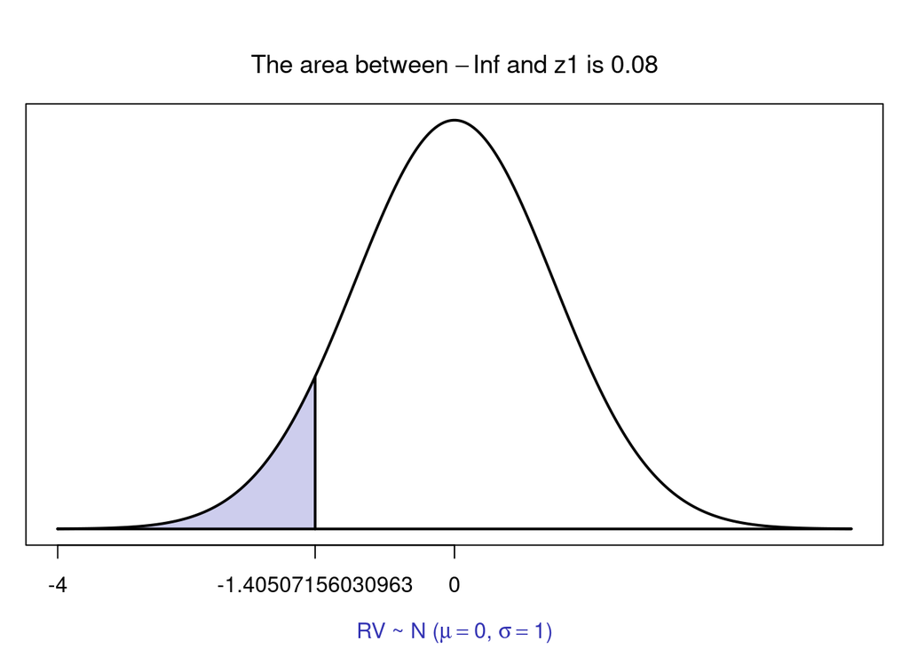

```r
normarea(-Inf, z1, 0, 1)
```

```r
z2 <- qnorm(0.90, 0, 1)
z2
```

```
[1] 1.281552
```

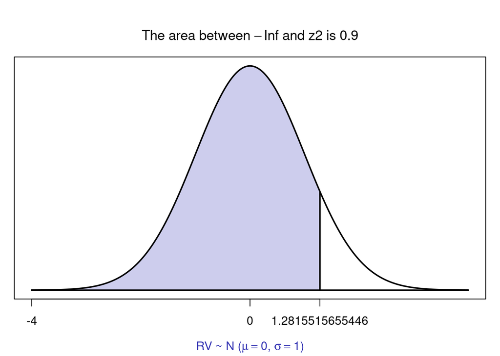

```r
normarea(-Inf, z2, 0, 1)
```

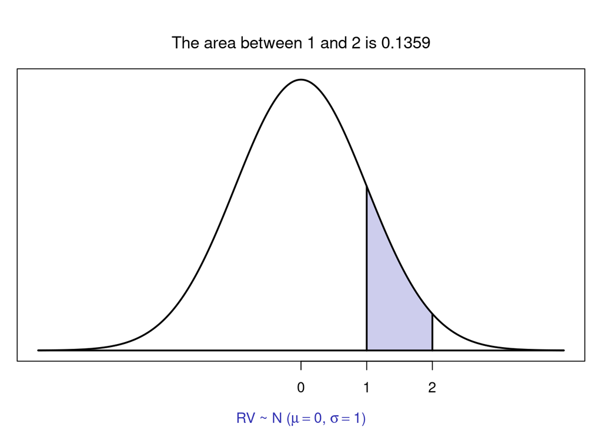

```r
# P(1 <= z <= 2)
normarea(1, 2, 0, 1)
```

```r
# Z_{0.05} = -Z_{0.95}
qnorm(0.05)
```

```
[1] -1.644854
```

```r
(-1)*qnorm(0.95)
```

```
[1] -1.644854
```

We know that $\hat{p} \dot\sim \mathcal{N}\left(p, \sqrt{\frac{p(1-p)}{n}}\right),$ so we can write

$$P\left(z_{\alpha/2} \leq \frac{\hat{p}-p}{\sqrt{\frac{p(1-p)}{n}}} \leq z_{1 - \alpha/2} \right)=1 -\alpha$$
Solve for $p$

Using some algebra,

$$P\left(\hat{p} - z_{1 - \alpha/2}\sqrt{\frac{p(1-p)}{n}} \leq p \leq \hat{p} - z_{\alpha/2}\sqrt{\frac{p(1-p)}{n}} \right)=1 -\alpha$$

$$P\left(\hat{p} - z_{1 - \alpha/2}\sqrt{\frac{p(1-p)}{n}} \leq p \leq \hat{p} + z_{1 -\alpha/2}\sqrt{\frac{p(1-p)}{n}} \right)=1 -\alpha$$

Substituting $\hat{p}$ for $p$ we get:

$$P\left(\hat{p} - z_{1 - \alpha/2}\sqrt{\frac{\hat{p}(1-\hat{p})}{n}} \leq p \leq \hat{p} + z_{1 -\alpha/2}\sqrt{\frac{\hat{p}(1-\hat{p})}{n}} \right)\approx 1 -\alpha$$

$$CI_{1 - \alpha}(p) = \left( \hat{p} \pm z_{1 - \alpha/2} \sqrt{\frac{\hat{p}(1-\hat{p})}{n}} \right)$$

Margin of error is what comes after the $\pm$.

We are $(1 - \alpha)\cdot 100$% confident that the true proportion lies in (lower, upper).

## Example

The Watauga Democrat polls a random sample of 330 voters and finds 144 who say they will vote yes on an upcoming referendum to increase school funding. Create a 95% CI for the percent of all voters who support the referendum.

**Check Conditions:**

1. **Randomization** — Given a random sample
2. **10%** — There are more than 3300 voters in Watauga County
3. **Success/Failure** — $(144/330)\cdot330 = 144 \geq 10$ and $330-144=186 \geq 10$.

```r
n <- 330
x <- 144
phat <- x/n
z <- qnorm(0.975)
CI <- phat + c(-1,1)*z*sqrt(phat*(1-phat)/n)
CI
```

```
[1] 0.3828561 0.4898712
```

```r
# Or
library(binom)
binom.confint(x = x, n = n, conf.level = 0.95, methods = "asymptotic") -> ACI
ACI
```

```
      method   x   n      mean     lower     upper
1 asymptotic 144 330 0.4363636 0.3828561 0.4898712
```

We are 95% confident the true proportion of voters who support the referendum falls in (0.3828561, 0.4898712) . Because the entire CI is below 50%, we are also more than 98% confident the referendum will **fail**.

Which is wider CI? 90% CL or 98% CL; $n = 10$ or $n = 100$

How can we cut the ME in half? **XXXX**

How can we cut the ME by $1/k$? **$k^2\cdot n$**

Agresti-Coull Interval $\rightarrow \tilde{p}=\frac{\text{Successes + 2}}{n = 4}$ and $\tilde{n} = n = 4$

This interval gives coverage probabilities closer to what is desired than the asymptotic CI for small and large $\hat{p}$.

Find a 95% Agresti-Coull CI for the percent of all voters who support the referendum.

```r
binom.confint(x = x, n = n, conf.level = 0.95, methods = "ac") -> AC_CI
AC_CI
```

```
         method   x   n      mean     lower     upper
1 agresti-coull 144 330 0.4363636 0.3838871 0.4903047
```

```r
#
nt <- 330 + 4
xt <- 144 + 2
pt <- xt/nt
z <- qnorm(0.975)
CI <- pt + c(-1,1)*z*sqrt(pt*(1-pt)/nt)
CI
```

```
[1] 0.3839292 0.4903223
```

We are 95% confident the true proportion of voters who support the referendum falls in (0.3838871, 0.4903047) . Because the entire CI is below 50%, we are also more than 98% confident the referendum will **fail**.

**Confidence Interval simulation of $p$**

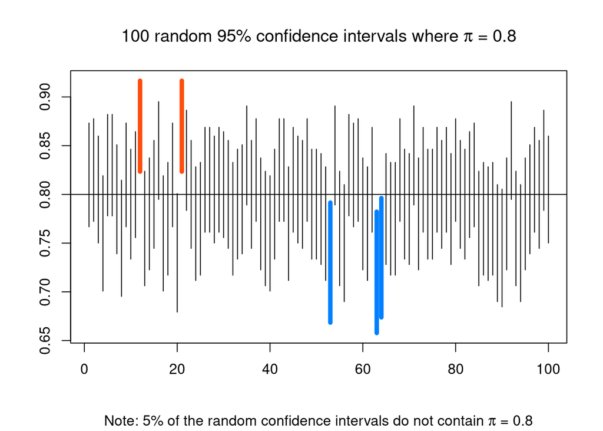

```
5% of the random confidence intervals do not contain Pi = 0.8.
```

```r
library(PASWR2)
set.seed(32)
cisim(100, 200, 0.8, type = "Pi", conf.level = 0.95)
```

# 2 Solving for sample size examples

## Example

The EU reports 46% of its work force is female. The US Department of Labor wants to calculate a similar statistic. How many records should they sample to know the percent of females in the labor force to within $\pm$ 5% with 90% confidence?

$$ME = z_{1 - \alpha/2}\sqrt{\frac{\hat{p}(1 - \hat{p})}{n}}$$
$$n = \left(\frac{z_{1 - \alpha/2}}{ME}\right)^2\cdot \left(\hat{p}\cdot(1 - \hat{p})\right)$$

```r
n <- ceiling((qnorm(.95)/.05)^2*(.46*.54))
n
```

```
[1] 269
```

```r
nsize(b = 0.05, p = .46, conf.level = .90, type = "pi")
```

```
The required sample size (n) to estimate the population
proportion of successes with a 0.9 confidence interval
so that the margin of error is no more than 0.05 is 269.
```

## Example

An environmental agency is concerned with the percent of cars violating clean air emissions standards. To estimate the true percent within 0.01 with a 99% confidence level, how many cars should they sample if a preliminary result gives 10% of cars?

```r
# YOUR CODE HERE
```

If the maximum margin of error is to be no more than 0.01, what sample size is needed?

Note the error is maximized when $\hat{p}=0.50$. Consider:

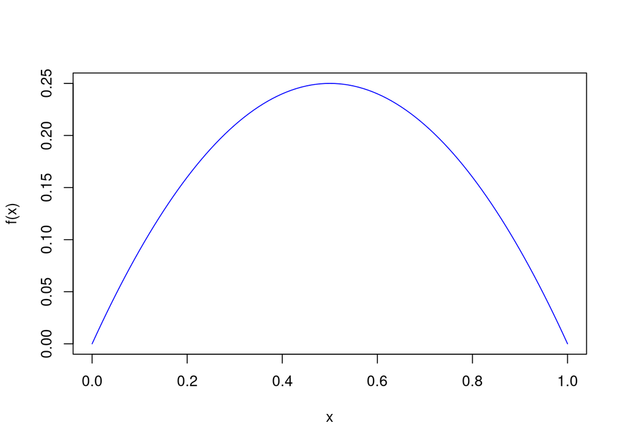

```r
f <- function(x){x - x^2}
curve(f, from = 0, to = 1, col = "blue")
```

```r
# YOUR CODE HERE
```

Read the “What can go wrong?” from this chapter carefully! The correct interpretation of a confidence interval can be linguistically tricky.